# Neural_Classification_Task_1

```python
# Importing Libraries

import numpy as np
import pandas as pd
import matplotlib.pyplot as plt
import tensorflow as tf
import seaborn as sns
from sklearn.preprocessing import StandardScaler
from sklearn.model_selection import train_test_split
```

```python
Obesity_Neural=pd.read_csv('ObesityDataset.csv')
```

UNDERSTANDING THE DATA

```python
Obesity_Neural.head()
```

|  | Gender | Age | Height | Weight | family_history_with_overweight | FAVC | FCVC | NCP | CAEC | SMOKE | CH2O | SCC | FAF | TUE | CALC | MTRANS | NObeyesdad |
| --- | --- | --- | --- | --- | --- | --- | --- | --- | --- | --- | --- | --- | --- | --- | --- | --- | --- |
| 0 | Female | 21.0 | 1.62 | 64.0 | yes | no | 2.0 | 3.0 | Sometimes | no | 2.0 | no | 0.0 | 1.0 | no | Public_Transportation | Normal_Weight |
| 1 | Female | 21.0 | 1.52 | 56.0 | yes | no | 3.0 | 3.0 | Sometimes | yes | 3.0 | yes | 3.0 | 0.0 | Sometimes | Public_Transportation | Normal_Weight |
| 2 | Male | 23.0 | 1.80 | 77.0 | yes | no | 2.0 | 3.0 | Sometimes | no | 2.0 | no | 2.0 | 1.0 | Frequently | Public_Transportation | Normal_Weight |
| 3 | Male | 27.0 | 1.80 | 87.0 | no | no | 3.0 | 3.0 | Sometimes | no | 2.0 | no | 2.0 | 0.0 | Frequently | Walking | Overweight_Level_I |
| 4 | Male | 22.0 | 1.78 | 89.8 | no | no | 2.0 | 1.0 | Sometimes | no | 2.0 | no | 0.0 | 0.0 | Sometimes | Public_Transportation | Overweight_Level_II |

```python
Obesity_Neural.tail()
```

|  | Gender | Age | Height | Weight | family_history_with_overweight | FAVC | FCVC | NCP | CAEC | SMOKE | CH2O | SCC | FAF | TUE | CALC | MTRANS | NObeyesdad |
| --- | --- | --- | --- | --- | --- | --- | --- | --- | --- | --- | --- | --- | --- | --- | --- | --- | --- |
| 2106 | Female | 20.976842 | 1.710730 | 131.408528 | yes | yes | 3.0 | 3.0 | Sometimes | no | 1.728139 | no | 1.676269 | 0.906247 | Sometimes | Public_Transportation | Obesity_Type_III |
| 2107 | Female | 21.982942 | 1.748584 | 133.742943 | yes | yes | 3.0 | 3.0 | Sometimes | no | 2.005130 | no | 1.341390 | 0.599270 | Sometimes | Public_Transportation | Obesity_Type_III |
| 2108 | Female | 22.524036 | 1.752206 | 133.689352 | yes | yes | 3.0 | 3.0 | Sometimes | no | 2.054193 | no | 1.414209 | 0.646288 | Sometimes | Public_Transportation | Obesity_Type_III |
| 2109 | Female | 24.361936 | 1.739450 | 133.346641 | yes | yes | 3.0 | 3.0 | Sometimes | no | 2.852339 | no | 1.139107 | 0.586035 | Sometimes | Public_Transportation | Obesity_Type_III |
| 2110 | Female | 23.664709 | 1.738836 | 133.472641 | yes | yes | 3.0 | 3.0 | Sometimes | no | 2.863513 | no | 1.026452 | 0.714137 | Sometimes | Public_Transportation | Obesity_Type_III |

```python
Obesity_Neural.describe
```

```
<bound method NDFrame.describe of       Gender        Age    Height      Weight family_history_with_overweight  \
0     Female  21.000000  1.620000   64.000000                            yes
1     Female  21.000000  1.520000   56.000000                            yes
2       Male  23.000000  1.800000   77.000000                            yes
3       Male  27.000000  1.800000   87.000000                             no
4       Male  22.000000  1.780000   89.800000                             no
...      ...        ...       ...         ...                            ...
2106  Female  20.976842  1.710730  131.408528                            yes
2107  Female  21.982942  1.748584  133.742943                            yes
2108  Female  22.524036  1.752206  133.689352                            yes
2109  Female  24.361936  1.739450  133.346641                            yes
2110  Female  23.664709  1.738836  133.472641                            yes

     FAVC  FCVC  NCP       CAEC SMOKE      CH2O  SCC       FAF       TUE  \
0      no   2.0  3.0  Sometimes    no  2.000000   no  0.000000  1.000000
```

[output cut: 25 more lines]

```python
Obesity_Neural.info()
```

```
<class 'pandas.core.frame.DataFrame'>
RangeIndex: 2111 entries, 0 to 2110
Data columns (total 17 columns):
 #   Column                          Non-Null Count  Dtype
---  ------                          --------------  -----
 0   Gender                          2111 non-null   object
 1   Age                             2111 non-null   float64
 2   Height                          2111 non-null   float64
 3   Weight                          2111 non-null   float64
 4   family_history_with_overweight  2111 non-null   object
 5   FAVC                            2111 non-null   object
 6   FCVC                            2111 non-null   float64
 7   NCP                             2111 non-null   float64
 8   CAEC                            2111 non-null   object
 9   SMOKE                           2111 non-null   object
 10  CH2O                            2111 non-null   float64
 11  SCC                             2111 non-null   object
 12  FAF                             2111 non-null   float64
 13  TUE                             2111 non-null   float64
 14  CALC                            2111 non-null   object
 15  MTRANS                          2111 non-null   object
 16  NObeyesdad                      2111 non-null   object
dtypes: float64(8), object(9)
memory usage: 280.5+ KB
```

```python
Obesity_Neural.shape
```

```
(2111, 17)
```

```python
Obesity_Neural['NObeyesdad'].value_counts()
```

```
Obesity_Type_I         351
Obesity_Type_III       324
Obesity_Type_II        297
Overweight_Level_I     290
Overweight_Level_II    290
Normal_Weight          287
Insufficient_Weight    272
Name: NObeyesdad, dtype: int64
```

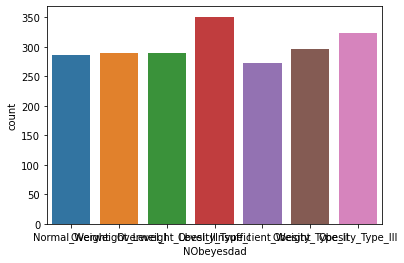

```python
sns.countplot(Obesity_Neural['NObeyesdad'])
```

REMOVING DUPLICATED ROWS

```python
Obesity_Neural.duplicated().sum()
```

```
24
```

```python
Obesity_Neural.drop_duplicates(keep='first').shape
```

```
(2087, 17)
```

CHANGING CATEGORICAL VARIABLES INTO NUMERIC

```python
Obesity_Neural.loc[:,["Age","Gender","family_history_with_overweight","CALC","MTRANS","SCC","FAVC","SMOKE","NObeyesdad"]]
```

[output not shown]

2111 rows × 9 columns

```python
print(Obesity_Neural['Gender'].nunique())
Obesity_Neural['Gender'].value_counts()
```

```
2
```

```
Male      1068
Female    1043
Name: Gender, dtype: int64
```

```python
Obesity_Neural["Gender"]=Obesity_Neural["Gender"].replace(["Male","Female"],[0,1])
```

```python
print(Obesity_Neural['family_history_with_overweight'].nunique())
Obesity_Neural['family_history_with_overweight'].value_counts()
```

```
2
```

```
yes    1726
no      385
Name: family_history_with_overweight, dtype: int64
```

```python
Obesity_Neural.family_history_with_overweight=Obesity_Neural.family_history_with_overweight.map({"yes":0,"no":1})
```

```python
print(Obesity_Neural['MTRANS'].nunique())
Obesity_Neural['MTRANS'].value_counts()
```

```
5
```

```
Public_Transportation    1580
Automobile                457
Walking                    56
Motorbike                  11
Bike                        7
Name: MTRANS, dtype: int64
```

```python
Obesity_Neural.MTRANS=Obesity_Neural.MTRANS.map({"Public_Transportation":0,"Automobile":1,"Walking":2,"Motorbike":3,"Bike":4})
```

```python
print(Obesity_Neural['SCC'].nunique())
Obesity_Neural['SCC'].value_counts()
```

```
2
```

```
no     2015
yes      96
Name: SCC, dtype: int64
```

```python
Obesity_Neural.SCC=Obesity_Neural.SCC.map({"yes":0,"no":1})
```

```python
print(Obesity_Neural['FAVC'].nunique())
Obesity_Neural['FAVC'].value_counts()
```

```
2
```

```
yes    1866
no      245
Name: FAVC, dtype: int64
```

```python
Obesity_Neural.FAVC=Obesity_Neural.FAVC.map({"yes":0,"no":1})
```

```python
print(Obesity_Neural['CAEC'].nunique())
Obesity_Neural['CAEC'].value_counts()
```

```
4
```

```
Sometimes     1765
Frequently     242
Always          53
no              51
Name: CAEC, dtype: int64
```

```python
Obesity_Neural.CAEC=Obesity_Neural.CAEC.map({"Sometimes":0,"no":1,"Frequently":2,"Always":3})
```

```python
print(Obesity_Neural['CALC'].nunique())
Obesity_Neural['CALC'].value_counts()
```

```
4
```

[output not shown]

```python
Obesity_Neural.CALC=Obesity_Neural.CALC.map({"Sometimes":0,"no":1,"Frequently":2,"Always":3})
```

```python
print(Obesity_Neural['SMOKE'].nunique())
Obesity_Neural['SMOKE'].value_counts()
```

```
2
```

```
no     2067
yes      44
Name: SMOKE, dtype: int64
```

```python
Obesity_Neural.SMOKE=Obesity_Neural.SMOKE.map({"yes":0,"no":1})
```

```python
print(Obesity_Neural['NObeyesdad'].nunique())
Obesity_Neural['NObeyesdad'].value_counts()
```

```
7
```

[output not shown]

```python
Obesity_Neural.NObeyesdad=Obesity_Neural.NObeyesdad.map({"Obesity_Type_I":0,"Obesity_Type_II":1,"Obesity_Type_III":2,"Overweight_Level_I":3,"Overweight_Level_II":4,"Normal_Weight":5,"Insufficient_Weight":6})
```

```python
Obesity_Neural.head()
```

|  | Gender | Age | Height | Weight | family_history_with_overweight | FAVC | FCVC | NCP | CAEC | SMOKE | CH2O | SCC | FAF | TUE | CALC | MTRANS | NObeyesdad |
| --- | --- | --- | --- | --- | --- | --- | --- | --- | --- | --- | --- | --- | --- | --- | --- | --- | --- |
| 0 | 1 | 21.0 | 1.62 | 64.0 | 0 | 1 | 2.0 | 3.0 | 0 | 1 | 2.0 | 1 | 0.0 | 1.0 | 1 | 0 | 5 |
| 1 | 1 | 21.0 | 1.52 | 56.0 | 0 | 1 | 3.0 | 3.0 | 0 | 0 | 3.0 | 0 | 3.0 | 0.0 | 0 | 0 | 5 |
| 2 | 0 | 23.0 | 1.80 | 77.0 | 0 | 1 | 2.0 | 3.0 | 0 | 1 | 2.0 | 1 | 2.0 | 1.0 | 2 | 0 | 5 |
| 3 | 0 | 27.0 | 1.80 | 87.0 | 1 | 1 | 3.0 | 3.0 | 0 | 1 | 2.0 | 1 | 2.0 | 0.0 | 2 | 2 | 3 |
| 4 | 0 | 22.0 | 1.78 | 89.8 | 1 | 1 | 2.0 | 1.0 | 0 | 1 | 2.0 | 1 | 0.0 | 0.0 | 0 | 0 | 4 |

DIVIDING THE MODEL INTO X(FOR OTHER VARIABLES) AND Y(For OBeyesday)

```python
X=Obesity_Neural.drop(columns='NObeyesdad',axis=1)
y=Obesity_Neural['NObeyesdad']
```

```python
print(X)
```

```
      Gender        Age    Height      Weight  family_history_with_overweight  \
0          1  21.000000  1.620000   64.000000                               0
1          1  21.000000  1.520000   56.000000                               0
2          0  23.000000  1.800000   77.000000                               0
3          0  27.000000  1.800000   87.000000                               1
4          0  22.000000  1.780000   89.800000                               1
...      ...        ...       ...         ...                             ...
2106       1  20.976842  1.710730  131.408528                               0
2107       1  21.982942  1.748584  133.742943                               0
2108       1  22.524036  1.752206  133.689352                               0
2109       1  24.361936  1.739450  133.346641                               0
2110       1  23.664709  1.738836  133.472641                               0

      FAVC  FCVC  NCP  CAEC  SMOKE      CH2O  SCC       FAF       TUE  CALC  \
0        1   2.0  3.0     0      1  2.000000    1  0.000000  1.000000     1
```

[output cut: 25 more lines]

```python
print(y)
```

```
0       5
1       5
2       5
3       3
4       4
       ..
2106    2
2107    2
2108    2
2109    2
2110    2
Name: NObeyesdad, Length: 2111, dtype: int64
```

USE OF TRAIN TEST SPLIT TO DIVIDE THE MODEL

```python
X_train,X_test,y_train,y_test= train_test_split(
    X,y,test_size=0.2,stratify=y,random_state=2)
```

```python
print(X.shape,X_train.shape,X_test.shape)
```

```
(2111, 16) (1688, 16) (423, 16)
```

```python
scaler=StandardScaler()
X_train=scaler.fit_transform(X_train)
X_test=scaler.transform(X_test)
```

BUILDING AND TRAINING THE NEURAL NETWORK WITH KERAS SEQUENTIAL MODEL

```python
model=tf.keras.models.Sequential()
model.add(tf.keras.layers.Dense(8,activation='relu',input_shape=(16,)))# we use 16 because there are 16x
model.add(tf.keras.layers.Dense(8,activation='softmax'))
```

COMIPLING THE MODEL BY SELECTING THE OPTIMIZER AND THE LOSS FUNCTION

```python
model.compile(optimizer='adam',
              loss='sparse_categorical_crossentropy',
              metrics='accuracy')
```

USE OF SUMMARY() TO VIEW THE NEURAL NETWORK BUILT

```python
model.summary()
```

```
Model: "sequential_6"
_________________________________________________________________
 Layer (type)                Output Shape              Param #
=================================================================
 dense_8 (Dense)             (None, 8)                 136

 dense_9 (Dense)             (None, 8)                 72

=================================================================
Total params: 208
Trainable params: 208
Non-trainable params: 0
_________________________________________________________________
```

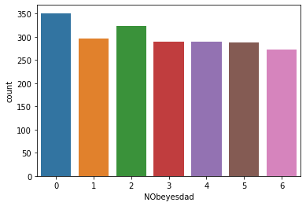

```python
sns.countplot(Obesity_Neural['NObeyesdad'])
```

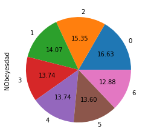

```python
Obesity_Neural['NObeyesdad'].value_counts().plot.pie(autopct='%.2f')
```

THERE IS A SMALL IMBALANCED CLASS.THERE ARE MORE OBSERVATIONS OF CLASS O AND 2. THIS WILL IMPACT MORE ON THE OVERALL VALUE OF THE LOSS FOR THESE THAN THE OTHER CLASSES. THE IMBALNCE THOuGH IS NOT CRITICAL.

```python
print(Obesity_Neural['NObeyesdad'].nunique())
Obesity_Neural['NObeyesdad'].value_counts()
```

```
7
```

```
0    351
2    324
1    297
3    290
4    290
5    287
6    272
Name: NObeyesdad, dtype: int64
```

```python
class weights= (0:1,1:6,2:7)
history=model.fit(X_train,y_train, \
                  botch_size=8,epochs=50, \
                  verbose=2,class_weight=class_weights,\
                  validation_plit=0.2)
```

```
  File "<ipython-input-127-97f3065067e9>", line 1
    class weights= (0:1,1:6,2:7)
                 ^
SyntaxError: invalid syntax
```

NEURAL NETWORK EVALUATION (REVIEW OF ACCURACY AND VALIDATION METRIC)

```python
acuracy=history.history['accuracy']
validation_accuracy=history.history['val_accuracy']

plt.plot(accuracy,label='Training Set Accuracy')
plt.plot(validation_accuracy,label='Validation Set Accuracy')
plt.ylabel('Accuracy')
plt.ylim([min(plt.ylim()),1])
plt.title('training and Validation Accuracy Across Epochs')
plt.legend()
```

[output not shown]

```python
loss=history.history['loss']
validation_loss=history.history['val_loss']

plt.plot(accuracy,label='Training Set Loss')
plt.plot(validation_accuracy,label='Validation Set Loss')
plt.ylabel('Loss')
plt.ylim([min(plt.ylim()),1])
plt.title('training and Validation Accuracy Across Epochs')
plt.legend()
```

[output not shown]

```python
from sklearn.metrics import confusion_matrix, classification_report
```

```python
y_pred = model.predict(X_test)
y_pred = y_pred.argmax(axis=1)
```

```python
confusion_matrix = confusion_matrix(y_test,y_pred)
ax sns.heatmap(confusion_matrix,cmap='flare',annot=True,fmt='d')

plt.xlabel("Predicted Class",fontsize=12)
plt.ylabel("True Class",fontsize=12)
plt.title("Confusion Matrix",fontsize=12)

plt.show()
```

[output not shown]